# Stats Notebook - Post Exam

Courtney Hodge

2024-07-30

7/30/24 Class

```r
insurance <- read.csv("C:\\Users\\hodge\\Desktop\\UVA_Coding_Folder\\Statistics-6021\\insurance.csv")
```

```r
#view(insurance)
```

```r
modl <- lm(charges~smoker, data=insurance)

summary(modl)
```

```
##
## Call:
## lm(formula = charges ~ smoker, data = insurance)
##
## Residuals:
##    Min     1Q Median     3Q    Max
## -19221  -5042   -919   3705  31720
##
## Coefficients:
##             Estimate Std. Error t value Pr(>|t|)
## (Intercept)   8434.3      229.0   36.83   <2e-16 ***
## smokeryes    23616.0      506.1   46.66   <2e-16 ***
## ---
## Signif. codes:  0 '***' 0.001 '**' 0.01 '*' 0.05 '.' 0.1 ' ' 1
##
## Residual standard error: 7470 on 1336 degrees of freedom
## Multiple R-squared:  0.6198, Adjusted R-squared:  0.6195
## F-statistic:  2178 on 1 and 1336 DF,  p-value: < 2.2e-16
```

```r
t.test(charges~smoker,data= insurance)
```

```
##
##  Welch Two Sample t-test
##
## data:  charges by smoker
## t = -32.752, df = 311.85, p-value < 2.2e-16
## alternative hypothesis: true difference in means between group no and group yes is not equal to 0
## 95 percent confidence interval:
##  -25034.71 -22197.21
## sample estimates:
##  mean in group no mean in group yes
##          8434.268         32050.232
```

```r
new <- data.frame(smoker="yes")
predict(modl, new)
```

```
##        1
## 32050.23
```

```r
mod2 <- lm(charges~region, data = insurance)
summary(mod2)
```

```
##
## Call:
## lm(formula = charges ~ region, data = insurance)
##
## Residuals:
##    Min     1Q Median     3Q    Max
## -13614  -8463  -3793   3385  49035
##
## Coefficients:
##                 Estimate Std. Error t value Pr(>|t|)
## (Intercept)      13406.4      671.3  19.971   <2e-16 ***
## regionnorthwest   -988.8      948.6  -1.042    0.297
## regionsoutheast   1329.0      922.9   1.440    0.150
## regionsouthwest  -1059.4      948.6  -1.117    0.264
## ---
## Signif. codes:  0 '***' 0.001 '**' 0.01 '*' 0.05 '.' 0.1 ' ' 1
##
## Residual standard error: 12080 on 1334 degrees of freedom
## Multiple R-squared:  0.006634,   Adjusted R-squared:  0.0044
## F-statistic:  2.97 on 3 and 1334 DF,  p-value: 0.03089
```

```r
insurance$region <-factor(insurance$region, levels = c("southeast", "northeast", "northwest", "southwest"))
```

```r
insurance$region2 <-factor(insurance$region, levels = c("southeast", "northeast", "northwest", "southwest"))

mod3 <- lm(charges~region2, data = insurance)
summary(mod3)
```

```
##
## Call:
## lm(formula = charges ~ region2, data = insurance)
##
## Residuals:
##    Min     1Q Median     3Q    Max
## -13614  -8463  -3793   3385  49035
##
## Coefficients:
##                  Estimate Std. Error t value Pr(>|t|)
## (Intercept)       14735.4      633.3  23.266   <2e-16 ***
## region2northeast  -1329.0      922.9  -1.440   0.1501
## region2northwest  -2317.8      922.2  -2.513   0.0121 *
## region2southwest  -2388.5      922.2  -2.590   0.0097 **
## ---
## Signif. codes:  0 '***' 0.001 '**' 0.01 '*' 0.05 '.' 0.1 ' ' 1
##
## Residual standard error: 12080 on 1334 degrees of freedom
## Multiple R-squared:  0.006634,   Adjusted R-squared:  0.0044
## F-statistic:  2.97 on 3 and 1334 DF,  p-value: 0.03089
```

```r
anov <- aov(charges~region, data = insurance)
```

> why are we doing all of this work? For the ANOVA test in this case, it is telling us that at the 5% level, we can go ahead and reject the null, meaning at least one of these means are different. What after? Tukey comparison to see which one is really different.

```r
TukeyHSD(anov)
```

```
##   Tukey multiple comparisons of means
##     95% family-wise confidence level
##
## Fit: aov(formula = charges ~ region, data = insurance)
##
## $region
##                           diff       lwr        upr     p adj
## northeast-southeast -1329.0269 -3702.996 1044.94167 0.4745046
## northwest-southeast -2317.8361 -4689.872   54.19944 0.0582938
## southwest-southeast -2388.4741 -4760.510  -16.43855 0.0476896
## northwest-northeast  -988.8091 -3428.934 1451.31605 0.7245243
## southwest-northeast -1059.4471 -3499.572 1380.67806 0.6792086
## southwest-northwest   -70.6380 -2508.883 2367.60656 0.9998516
```

> At least we can see which of theintervals are both negative. Southwest tells us that on average, southwest is lover than southeast.

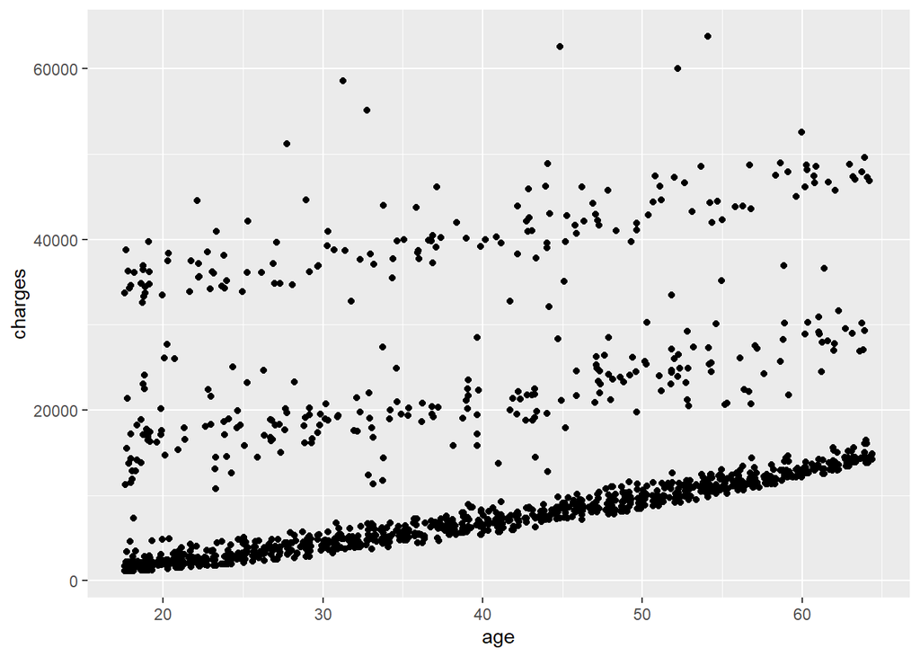

```r
library(ggplot2)
ggplot(insurance, aes(x = age, y = charges)) + geom_jitter()
```

> IF we fit the model above, do you think it will be agood model? The answer is no.

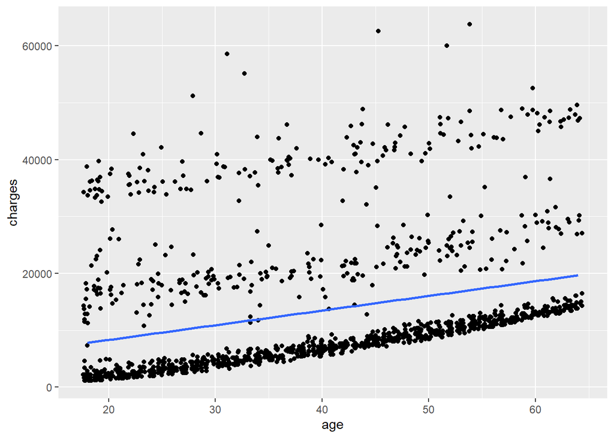

```r
library(ggplot2)
ggplot(insurance, aes(x = age, y = charges)) + geom_jitter() + geom_smooth(method = "lm", se = F)
```

> we can see that the line is actually trying to do the middle of smoker charges instead of non-smoker charges.

> we are going to color the dots based on the smoker status. Now, we can see what’s really going on and this is why **data exploration is important**. All the outliers, the high charges, on average, cooresponds to smokers.

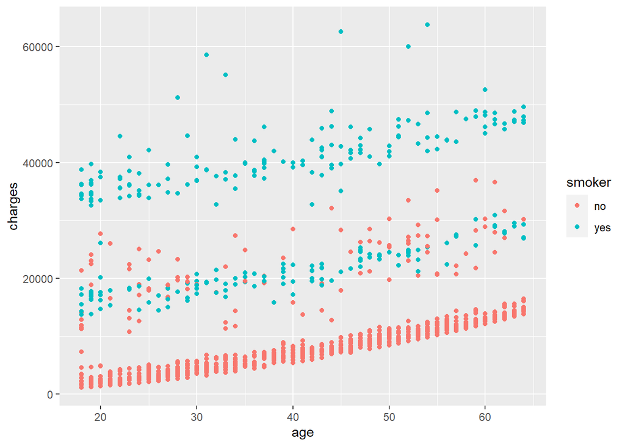

```r
library(ggplot2)
ggplot(insurance, aes(x = age, y = charges, color = smoker)) + geom_point()
```

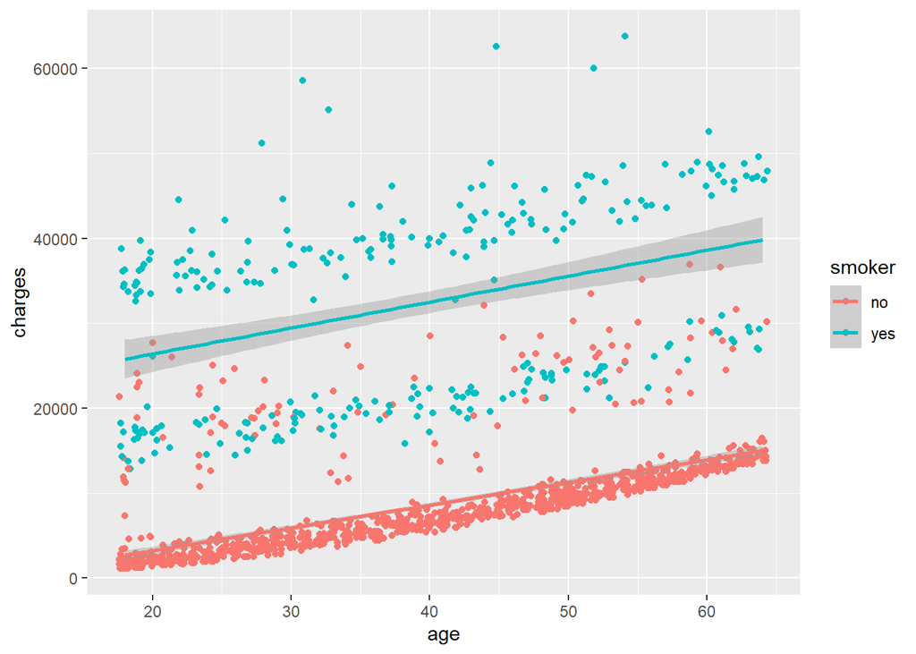

```r
library(ggplot2)
ggplot(insurance, aes(x = age, y = charges, color = smoker)) + geom_jitter() + geom_smooth(method = "lm", aes(group = smoker))
```

> now, we have two lines. one that makes a predictor for smokers and one that makes a predictor for non-smokers. Before we build the model, we will have an indicator function that fits the model.

```r
mod4<- lm(charges~age + smoker, data = insurance)
summary(mod4)
```

```
##
## Call:
## lm(formula = charges ~ age + smoker, data = insurance)
##
## Residuals:
##      Min       1Q   Median       3Q      Max
## -16088.1  -2046.8  -1336.4   -212.7  28760.0
##
## Coefficients:
##             Estimate Std. Error t value Pr(>|t|)
## (Intercept) -2391.63     528.30  -4.527 6.52e-06 ***
## age           274.87      12.46  22.069  < 2e-16 ***
## smokeryes   23855.30     433.49  55.031  < 2e-16 ***
## ---
## Signif. codes:  0 '***' 0.001 '**' 0.01 '*' 0.05 '.' 0.1 ' ' 1
##
## Residual standard error: 6397 on 1335 degrees of freedom
## Multiple R-squared:  0.7214, Adjusted R-squared:  0.721
## F-statistic:  1728 on 2 and 1335 DF,  p-value: < 2.2e-16
```

## Using Dummy Variables to capture Interactions Between Explanatory Variables

```r
mod5 <- lm(charges~age * smoker, data = insurance)
summary(mod5)
```

```
##
## Call:
## lm(formula = charges ~ age * smoker, data = insurance)
##
## Residuals:
##      Min       1Q   Median       3Q      Max
## -16072.5  -2043.0  -1348.7   -258.9  28814.6
##
## Coefficients:
##               Estimate Std. Error t value Pr(>|t|)
## (Intercept)   -2091.42     582.57  -3.590 0.000343 ***
## age             267.25      13.93  19.187  < 2e-16 ***
## smokeryes     22385.55    1278.73  17.506  < 2e-16 ***
## age:smokeryes    37.99      31.09   1.222 0.222037
## ---
## Signif. codes:  0 '***' 0.001 '**' 0.01 '*' 0.05 '.' 0.1 ' ' 1
##
## Residual standard error: 6396 on 1334 degrees of freedom
## Multiple R-squared:  0.7217, Adjusted R-squared:  0.7211
## F-statistic:  1153 on 3 and 1334 DF,  p-value: < 2.2e-16
```

> Every time your age incrases by 1, your smokers will increase by 267.25 + 37.99.

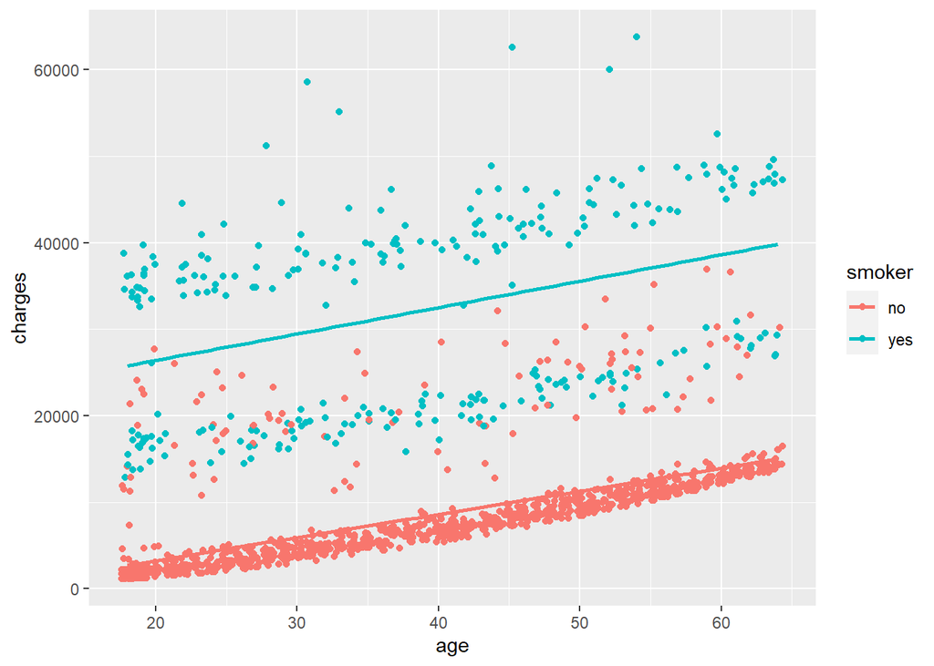

```r
ggplot(insurance, aes(x = age, y = charges, color = smoker)) + geom_jitter() + geom_smooth(method = "lm", model.extract(mod5), se = F)
```

```r
new_dat <- data.frame(age=26, smoker = "no")
predict(mod5, new_dat,interval = "prediction")
```

```
##        fit       lwr      upr
## 1 4857.051 -7700.646 17414.75
```

## building a model with everything

```r
ins <- insurance[,-8]
```

```r
mod10 <- lm(charges~., data = ins)
summary(mod10)
```

```
##
## Call:
## lm(formula = charges ~ ., data = ins)
##
## Residuals:
##      Min       1Q   Median       3Q      Max
## -11304.9  -2848.1   -982.1   1393.9  29992.8
##
## Coefficients:
##                  Estimate Std. Error t value Pr(>|t|)
## (Intercept)     -12973.56    1079.16 -12.022  < 2e-16 ***
## age                256.86      11.90  21.587  < 2e-16 ***
## sexmale           -131.31     332.95  -0.394 0.693348
## bmi                339.19      28.60  11.860  < 2e-16 ***
## children           475.50     137.80   3.451 0.000577 ***
## smokeryes        23848.53     413.15  57.723  < 2e-16 ***
## regionnortheast   1035.02     478.69   2.162 0.030782 *
## regionnorthwest    682.06     478.96   1.424 0.154669
## regionsouthwest     74.97     470.64   0.159 0.873460
## ---
## Signif. codes:  0 '***' 0.001 '**' 0.01 '*' 0.05 '.' 0.1 ' ' 1
##
## Residual standard error: 6062 on 1329 degrees of freedom
## Multiple R-squared:  0.7509, Adjusted R-squared:  0.7494
## F-statistic: 500.8 on 8 and 1329 DF,  p-value: < 2.2e-16
```

> the residual standard error meausres how well we are going to do. This model will error in health care coverage by about $6,062 dolalrs. SSE (sum of squared error) from the population model. MSE = SSE/(n-p-1) is the residual standard error. SSE/n

## Outliers

> leverage points, influential points, outliers how do you use your model to get rid of some of these variables if they are presenting a big change to our model

> Outlier: Outliers are data points with the largest residuals. Detection:
1. Scatterplot
2. Residual Plot
3. Standardized Residuals: Residuals divided by their estimated standard deviation.

> An outlier can be an x-outlier (when predictor variable has an unusual value) or a y-outlier (when residual variable has an unusual value).

> Treating Outliers: 1. Transform response 2. Consider context and subject matter knowledge 3. Measurement error> 4. Winsorize: Replace extreme valeus with the nearest values that are not outliers. For ex., replace valeues about the 95th percentile with the value at the 95th percentile 5. Trim/revmove point (last resort) 6. Use other techniques like quantile regression or Random Forest which are resistant to outliers.

> Treating High Leverage Points 1. Transform predicor 2. COnsider context and subject matter knowledge . . .

## Influential Points

> influential points : data points that have a disproportionately large impact on the regression model’s coefficients and fitted values. Detection: Cook’s Distance: One common measure to identify influential points in Cook’s distance. IF a point has a Cook’s distance signficantly larger than others, it is condsidered influential.

```r
#install.packages("broom")
```

```r
library(broom)
library(dplyr)
dat_ins <- mod5 |> augment(ins)
```

```r
filter(dat_ins, .std.resid > 2)
```

```
## # A tibble: 74 × 13
##      age sex      bmi children smoker region    charges .fitted .resid    .hat
##    <int> <chr>  <dbl>    <int> <chr>  <fct>       <dbl>   <dbl>  <dbl>   <dbl>
##  1    33 male    22.7        0 no     northwest  21984.   6728. 15257. 0.00113
##  2    60 female  25.8        0 no     northwest  28923.  13944. 14980. 0.00296
##  3    28 male    36.4        1 yes    southwest  51195.  28841. 22354. 0.00574
##  4    64 male    24.7        1 no     northwest  30167.  15013. 15154. 0.00381
##  5    18 female  30.1        0 no     northeast  21345.   2719. 18626. 0.00311
##  6    60 male    28.6        0 no     northeast  30260.  13944. 16316. 0.00296
##  7    54 female  31.9        3 no     southeast  27323.  12340. 14983. 0.00195
##  8    34 male    22.4        2 no     northeast  27376.   6995. 20381. 0.00108
##  9    24 female  23.2        0 no     southeast  25082.   4323. 20759. 0.00206
## 10    55 female  26.8        1 no     southwest  35160.  12607. 22553. 0.00210
## # ℹ 64 more rows
## # ℹ 3 more variables: .sigma <dbl>, .cooksd <dbl>, .std.resid <dbl>
```

> according to this data and this metric, all these points, 74 observations will not meet this criteria.

7/31/24

```r
library(tidyverse)
library(broom)
```

> we will build a model w/ all the variables and then decide which ones we’ll drop

```r
model1<-lm(charges~., data = insurance)
summary(model1)
```

```
##
## Call:
## lm(formula = charges ~ ., data = insurance)
##
## Residuals:
##      Min       1Q   Median       3Q      Max
## -11304.9  -2848.1   -982.1   1393.9  29992.8
##
## Coefficients: (3 not defined because of singularities)
##                   Estimate Std. Error t value Pr(>|t|)
## (Intercept)      -12973.56    1079.16 -12.022  < 2e-16 ***
## age                 256.86      11.90  21.587  < 2e-16 ***
## sexmale            -131.31     332.95  -0.394 0.693348
## bmi                 339.19      28.60  11.860  < 2e-16 ***
## children            475.50     137.80   3.451 0.000577 ***
## smokeryes         23848.53     413.15  57.723  < 2e-16 ***
## regionnortheast    1035.02     478.69   2.162 0.030782 *
## regionnorthwest     682.06     478.96   1.424 0.154669
## regionsouthwest      74.97     470.64   0.159 0.873460
## region2northeast        NA         NA      NA       NA
## region2northwest        NA         NA      NA       NA
## region2southwest        NA         NA      NA       NA
## ---
## Signif. codes:  0 '***' 0.001 '**' 0.01 '*' 0.05 '.' 0.1 ' ' 1
##
## Residual standard error: 6062 on 1329 degrees of freedom
## Multiple R-squared:  0.7509, Adjusted R-squared:  0.7494
## F-statistic: 500.8 on 8 and 1329 DF,  p-value: < 2.2e-16
```

> we use augment to get our predictions (.fitted), our actual charges, all our residuals (.resid), all of our leverages (.hat), and our cook distance (.cooksd), and one for all of our outliers (.std.resid)

```r
diagnostics <- model1 |> augment(data = insurance)
```

> we will filter our dataset to look at any outliers outside 3. we are going to get this our and have a dataset of all outliers for all observations that meet this restriction, we will call it an outlier

```r
outliers <- filter(diagnostics, abs(.std.resid) > 3)
```

> same thing for leverage (.hat). Let’s create

```r
leverage <- filter(diagnostics, .hat>2*(6 + 1)/nrow(insurance))
```

> same for influence (.cooksd), let’s find our outliers

```r
influence <- filter(diagnostics, .cooksd>4 / nrow(insurance))

#view(insurance)
```

> Now, we will address how our model will do when we have other things affecting it? within this dataset, our model is great, but with new values, how will this change

## Model Complexity, Overfitting/Underfitting

- Model complexity refers to the sophistication of flexibility of a model in capturing relationships between predictors and the response variable. In simple terms, it reflects how intricate the model is in representing the underlying patterns in the data
- Underfitting/Overfitting: model complexity is a crucial consideration in machine learning because overly simple models may underfit the data, failing to capture important patterns, while overly complex models may overfit the data, capturing noise instead of true underflying relationships. Achieving the right balance of complexity is essential for building modeles that generalize well to unseen data

Solutions:

1. Bootstrapping
2. Train-Test Split
3. Cross-Validation
4. Regularization

Model Performance Metrics:

There are several ways to measure the performance of a predictive model. For linear models, metrics include * R^2 and Adjusted R^2 * Root Mean Squared Error (RMSE) * Mean Absolute Error (MAE)

WHY ARE WE DOING THIS? * If we have two different models (one with charges~. and one with charge~ (everything but sex)), we want the smallest RMSE. Let’s write some code to do this in a simple case.

> Train Test Split Example
- Remember, this is without replacement!!!!

```r
#make sure to specify the split size
#80% of 1338 is not a descrete (whole) number. Make sure to use floor or ceiling functions
split <- sample(1:nrow(insurance), size = floor(0.8*nrow(insurance)))


train_data <-insurance[split,]
test_data <- insurance[-split, ]
```

> now that we have the test and train, we will build our model

```r
model2 <- lm(charges~age + bmi + children + smoker + region, data = train_data)

summary(model2)
```

```
##
## Call:
## lm(formula = charges ~ age + bmi + children + smoker + region,
##     data = train_data)
##
## Residuals:
##      Min       1Q   Median       3Q      Max
## -12328.1  -2725.7   -945.3   1232.0  29313.2
##
## Coefficients:
##                  Estimate Std. Error t value Pr(>|t|)
## (Intercept)     -11804.46    1188.88  -9.929   <2e-16 ***
## age                255.55      13.20  19.362   <2e-16 ***
## bmi                308.35      31.36   9.832   <2e-16 ***
## children           394.20     155.41   2.536   0.0113 *
## smokeryes        24223.13     462.58  52.366   <2e-16 ***
## regionnortheast    726.13     530.48   1.369   0.1713
## regionnorthwest    243.16     533.44   0.456   0.6486
## regionsouthwest     68.26     524.47   0.130   0.8965
## ---
## Signif. codes:  0 '***' 0.001 '**' 0.01 '*' 0.05 '.' 0.1 ' ' 1
##
## Residual standard error: 6030 on 1062 degrees of freedom
## Multiple R-squared:  0.7533, Adjusted R-squared:  0.7516
## F-statistic: 463.1 on 7 and 1062 DF,  p-value: < 2.2e-16
```

> **NOW, let’s see how good our model is**

```r
#(new data, test data)
predictions <- predict(model2, test_data)

#Root Mean Squared Error
rmse <- sqrt(mean((predictions - test_data$charges) ^ 2))

rmse
```

```
## [1] 6216.949
```

```r
#we could also just call the RMSE function
#RMSE(predictions, test_data$charges)

#^ there's an error, so be careful
```

> If we wanted to find the MAE, we could just take the absolute value of (ysubi - ysubi hat)